# dependent t-test

nacoker

2/23/2021

## Importing an Excel data file from the desktop

To import the data file, the readxl package must be loaded. Start by specifying the file path in quotes. If the spreadsheet has multiple pages, you can specify the name of the specific sheet you want to read in using the “sheet” parameter.

```r
library(readxl)
pre.data<-read_excel("C:/Users/ncoker/Desktop/t-test sample files.xlsx",sheet="missing-dependent")
dependent<-as.data.frame(pre.data)
```

Using the “head” function displays the headers as well as the first six rows of data, as you can see below.Any missing values are listed as “NA”.

```r
head(dependent)
```

```
##   subject max-pre max-post
## 1       1   130.0    140.0
## 2       2   140.0    107.5
## 3       3      NA    117.5
## 4       4   115.0    120.0
## 5       5   102.5    160.0
## 6       6   110.0    110.0
```

## Creating histograms

To visualize the data, we can plot a histogram using the “qplot” function, with the 1RM in kilograms displayed on the x-axis and the frequency of occurrences of each value on the y-axis. This requires the ‘ggplot2’ package. The binwidth will set the limits of each tick along the x-axis, so may need to be adjusted to better fit your data. Below, you can see the histograms of both the pre and post data from the dependent data frame

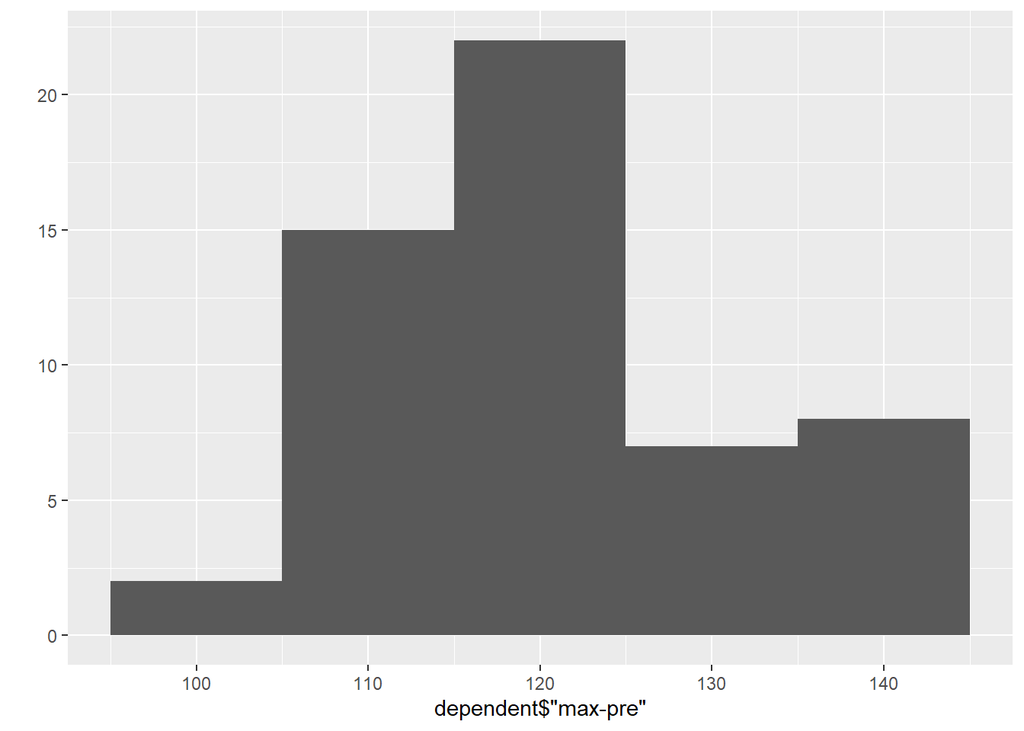

```r
library(ggplot2)
pre<-qplot(dependent$'max-pre',geom="histogram",binwidth=10)
plot(pre)
```

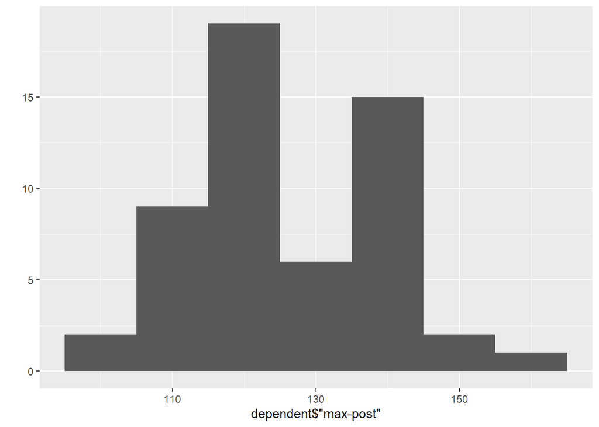

```r
post<-qplot(dependent$'max-post',geom="histogram",binwidth=10)
plot(post)
```

We can then use the “grid.arrange” and “labs” functions to change the look of our plots:

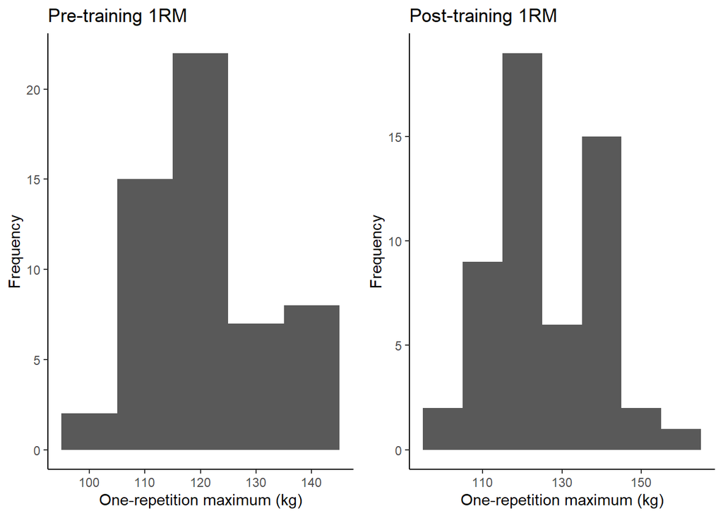

```r
library(gridExtra)
pre<-pre+labs(title="Pre-training 1RM",x="One-repetition maximum (kg)",y="Frequency")+theme_classic()
post<-post+labs(title="Post-training 1RM",x="One-repetition maximum (kg)",y="Frequency")+theme_classic()
prepost<-grid.arrange(pre,post,nrow=1)
```

# Shapiro-Wilk test for Normality

In addition to creating a histogram for visual inspection of the data, we can also statistically test the assumption of normality using the Shapiro-Wilk test:

```r
pre.norm<-shapiro.test(dependent$'max-pre')
post.norm<-shapiro.test(dependent$'max-post')
pre.norm
```

```
##
##  Shapiro-Wilk normality test
##
## data:  dependent$"max-pre"
## W = 0.96274, p-value = 0.09146
```

```r
post.norm
```

```
##
##  Shapiro-Wilk normality test
##
## data:  dependent$"max-post"
## W = 0.96507, p-value = 0.1164
```

Based on these results and the histograms, we can assume that data are normally distributed, satisfying the primary assumption of a dependent t-test.

# Running the t-test

Now that we have tested our assumptions, we are ready to run the t-test. We can do this using the “t.test” function, specifying the parameters of our model. In this example, I chose to run a one-tailed test because we would expect that the majority of participants respond positively to a resistance training intervention for measures of maximal strength. This is done by specifying “alternative=less” because we assume that the post value is higher than the pre value. I also set var.equal=TRUE because equal variance is assumed in a paired samples test, and paired=TRUE to specify a paired samples test.

```r
result<-t.test(dependent$'max-pre',dependent$'max-post',data=my_data,alternative="less",var.equal=TRUE,paired=TRUE)
result
```

```
##
##  Paired t-test
##
## data:  dependent$"max-pre" and dependent$"max-post"
## t = -1.7585, df = 47, p-value = 0.04259
## alternative hypothesis: true difference in means is less than 0
## 95 percent confidence interval:
##        -Inf -0.2218068
## sample estimates:
## mean of the differences
##                -4.84375
```

As we can see here, our p-value is 0.04259, indicating that there was a significant increase in 1RM strength over the course of the training intervention.